# Simulation Results

2024-07-25

## Network generation

In the following simulations, we generate bipartite networks by first simulating the corresponding latent space. The latent space, or a transformation of it, will be use as covariates in the model. The key difference between simulation settings is not the network generation method, but the manner in which the available covariates are incorporated into the model.

Let $n_1= 1000$ and $n_2=100$, let $D_+$ be an integer, let $D_- = D_+$ and let $D=D_+ + D_-$. Let $Z_1^+\in\mathbb{R}^{n_1 \times D_+}$ and $Z_1^-\in\mathbb{R}^{n_1 \times D_-}$ such as $Z_{1_{i,j}}^+\overset{i.i.d.}{\sim} \mathcal{N}(0,1)$ and $Z_{1_{i,j}}^-\overset{i.i.d.}{\sim} \mathcal{N}(0,1)$ independent of $Z_1^+$. Let $Z_1 = \left[Z_1^+| Z_1^- \right]$ be the concatenation of $Z_1^+$ and $Z_1^-$. Let $Z_2\in\mathbb{R}^{n_2 \times D}$ such as $Z_{2_{i,j}}^+\overset{i.i.d.}{\sim} \mathcal{N}(1,1)$. For $1\leq i\leq n_1$, $Z_{1i}\in\mathbb{R}^{D}$ represents the $i$-th row of $Z_1$. Similarly, $Z_{2j}\in\mathbb{R}^{D}$ represents the $j$-th row of $Z_2$. Finally, our bipartite adjacency matrix is simulated with a Bernoulli distribution $B_{i,j} \overset{i.i.d.}{\sim} \mathcal{B}(sigmoid(Z_{1i}^\top\mathbf{I}_{D_+,D_-}Z_{2j}))$. $Z_1$ and $Z_2$ are respectively row nodes and column nodes latent representation of the generated network. Given how the network is constructed, higher values of $Z_1^+$ are expected to be positively correlated with connectivity, while higher values of $Z_1^-$ are expected to be negatively correlated with connectivity.

## GNN inputs

In the following part, we summarize how we construct the observed $X_1$ that will be use as a covariate to fit the model. To improve readability, we will change the notation from $Z_1$ to $Z$. Let $D_0$ be an integer and let $X_1^0 \in \mathbb{R}^{n_1 \times D_0}$ be a noise matrix with ${X}^0_{i,j}\overset{i.i.d.}{\sim} \mathcal{N}(0,1)$. The $n_1$ row nodes are partitioned into $K$ groups, node $i$ belongs to group $Q[i]$ with $Q[i]\in \{1,\dots,K\}$. If there are no groups, then $K=1$. For $1\leq k \leq K, 1\leq j \leq D$, $\gamma_{k,j}\in \{-1,0,1\}$ describes the combined effect of group $k$ on the covariate $j$. The set of value taken by $\gamma$ can change depending on the simulation setting. For $1\leq i \leq n_1, 1\leq j \leq D$, let $X$ such as
$$X_{i,j}= \left\{
\begin{array}{ll}
\ \gamma_{Q[i],j}Z_{i,j}& \mbox{if } \gamma_{Q[i],j}\neq 0
\\
\\
\xi_{i,j}\mbox{ with } \xi_{i,j}\overset{i.i.d.}{\sim}
\mathcal{N}(0,1) & \mbox{if } \gamma_{Q[i],j}=0
\end{array}
\right.$$
Finally, we define
$$X_1 =
\left[H|X|X^0 \right]$$
where $H$ is additional variables. $X_2 = \mathbf{1}_{n_2}$ is a column made of $1$. BGVAE is trained with adjacency matrix $B$ and covariates $X_1,X_2$. The learning can also be done with the fair-BGVAE. In this case, some input columns of $X_1$ are selected and the learning is penalized by the HSIC between the estimated latent space and these columns. Once the model trained, previously described attribution methods are fit on $f_{\widehat{B}}(X_1)$ to study the impact of the features of $X_1$ on connectivity.

## Settings

Parameter settings are presented in the following table. We remind that the true latent space is of size $D = D_+ + D_-$ with $D_+ = D_-$, and $D_0$ is the number of the noise covariates. $K$ is the number of groups. $\Gamma$ represents the set of value possibily taken by $\gamma$. The HSIC columns determine how much columns of $X_1$ are penalized by the HSIC during the learning of the Fair BVGAE, empty values correspond to classical BVGAE learning. $H$ corresponds to the additional variables.

Parameter table

|  | $D_+$ | $D_0$ | K | $\Gamma$ | HSIC | $H$ |
| --- | --- | --- | --- | --- | --- | --- |
| 0 | 3 | 3 | 1 | $\{1\}$ | _ | $\mathbf{1}_{n_1}$ |
| 1 | 3 | 3 | 1 | $\{1\}$ | _ | $\mathbf{1}_{n_1}$ |
| 2 | 3 | 50 | 1 | $\{1\}$ | _ | $\mathbf{1}_{n_1}$ |
| 3 | 3 | 50 | 1 | $\{1\}$ | _ | $\mathbf{1}_{n_1}$ |
| 4 | 1 | 1 | 2 | $\{1,-1\}$ | _ | $\mathbf{1}_{n_1}$ |
| 5 | 3 | 50 | 2 | $\{1,-1\}$ | _ | $\mathbf{1}_{n_1}$ |
| 6 | 3 | 6 | 2 | $\{1,0,-1\}$ | _ | $\mathbf{1}_{n_1}$ |
| 7 | 3 | 6 | 2 | $\{1,-1\}$ | _ | $[\mathbf{1}_{n_1},P]$ |
| 8 | 3 | 6 | 4 | $\{1,0,-1\}$ | _ | $\mathbf{1}_{n_1}$ |
| 9 | 3 | 6 | 4 | $\{1,0,-1\}$ | _ | $[\mathbf{1}_{n_1},P]$ |
| 10 | 3 | 1 | 1 | $\{1\}$ | 2 | $\mathbf{1}_{n_1}$ |
| 11 | 4 | 50 | 2 | $\{1,-1\}$ | 2 | $\mathbf{1}_{n_1}$ |
| 12 | 4 | 8 | 4 | $\{1,0,-1\}$ | 2 | $\mathbf{1}_{n_1}$ |
| 13 | 4 | 8 | 4 | $\{1,0,-1\}$ | 2 | $[\mathbf{1}_{n_1},P]$ |

## Results

For all simulations, the AUC for link prediction with and without covariates are displayed to demonstrate the impact of covariates on the model’s learning.

### Simulation 0

Easiest simulation

- 3 covariates have a positive effect
- 3 covariates have a negative effect
- 3 covariates have no effect
- The algorithm is trained with all the covariates

```
## [1] "AUC without covariates: 0.498"
```

```
## [1] "AUC with covariates: 0.716"
```

|  | GraphSVX | GRAD | GRADxInput | IG |
| --- | --- | --- | --- | --- |
| + | 1.00 | 1.00 | 0.88 | 0.99 |
| - | 0.00 | 1.00 | 0.11 | 0.00 |
| AUC | 0.98 | 0.85 | 0.85 | 0.98 |

- The dashed line is positioned at zero.
- The black dot represents the estimated score for the additional variables $H$.
- The green dots represent the estimated score for features where positive values are expected.
- The red dots represent the estimated score for features where negative values are expected.
- The blue dots are scores attributed to noise.

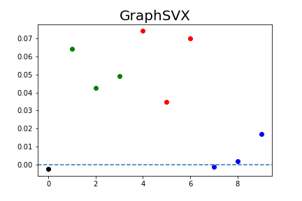

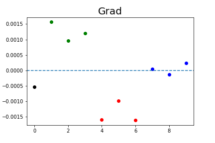

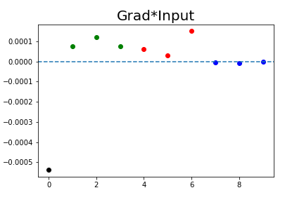

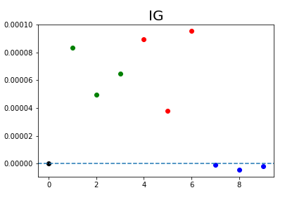

### Simulation 1

The network is generated with

- 3 covariates have a positive effect
- 3 covariates have a negative effect

The algorithm is trained with

- 2 covariates with positive effect
- 2 covariates with negative effect
- 3 covariates with no effect

```
## [1] "AUC without covariates: 0.498"
```

```
## [1] "AUC with covariates: 0.738"
```

|  | GraphSVX | GRAD | GRADxInput | IG |
| --- | --- | --- | --- | --- |
| + | 0.53 | 1.00 | 0.27 | 0.50 |
| - | 0.47 | 0.98 | 0.70 | 0.52 |
| AUC | 0.74 | 0.12 | 0.68 | 0.75 |

- The dashed line is positioned at zero.
- The black dot represents the estimated score for the additional variables $H$.
- The green dots represent the estimated score for features where positive values are expected.
- The red dots represent the estimated score for features where negative values are expected.
- The blue dots are scores attributed to noise.

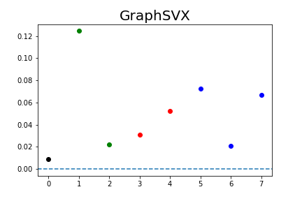

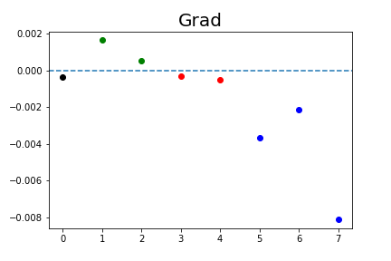

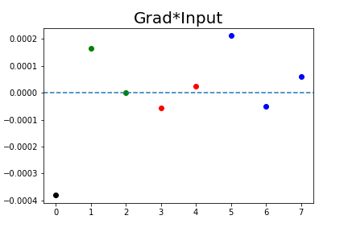

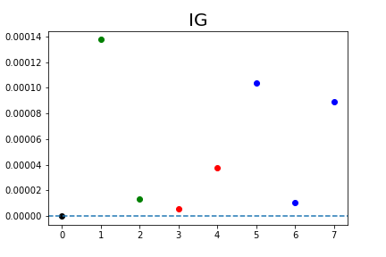

### Simulation 2

- 3 covariates have a positive effect
- 3 covariates have a negative effect
- 50 covariates have no effect
- The algorithm is trained with all the covariates

```
## [1] "AUC without covariates: 0.496"
```

```
## [1] "AUC with covariates: 0.751"
```

|  | GraphSVX | GRAD | GRADxInput | IG |
| --- | --- | --- | --- | --- |
| + | 1 | 1.00 | 1.00 | 1 |
| - | 0 | 1.00 | 0.01 | 0 |
| AUC | 1 | 0.88 | 0.98 | 1 |

- The dashed line is positioned at zero.
- The black dot represents the estimated score for the additional variables $H$.
- The green dots represent the estimated score for features where positive values are expected.
- The red dots represent the estimated score for features where negative values are expected.
- The blue dots are scores attributed to noise.

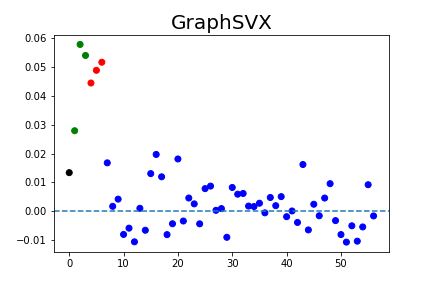

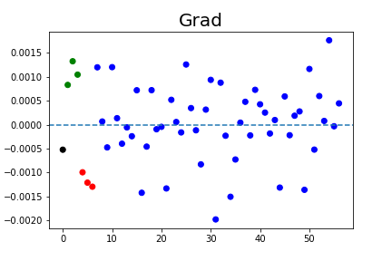

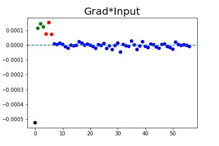

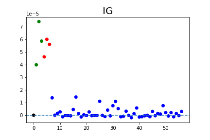

### Simulation 3

The network is generated with

- 3 covariates with a positive effect
- 3 covariates with a negative effect

The algorithm is trained with

- 2 covariates with positive effect
- 2 covariates with negative effect
- 50 covariates have no effect

```
## [1] "AUC without covariates: 0.497"
```

```
## [1] "AUC with covariates: 0.748"
```

|  | GraphSVX | GRAD | GRADxInput | IG |
| --- | --- | --- | --- | --- |
| + | 1.00 | 1.0 | 0.98 | 1.00 |
| - | 0.00 | 1.0 | 0.08 | 0.02 |
| AUC | 0.99 | 0.7 | 0.94 | 1.00 |

- The dashed line is positioned at zero.
- The black dot represents the estimated score for the additional variables $H$.
- The green dots represent the estimated score for features where positive values are expected.
- The red dots represent the estimated score for features where negative values are expected.
- The blue dots are scores attributed to noise.

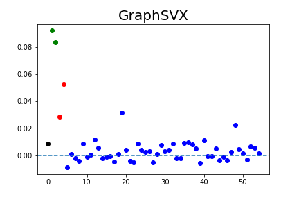

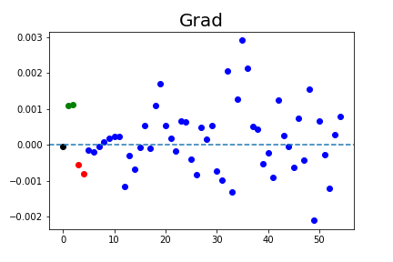

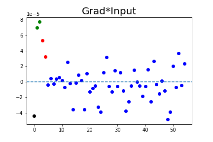

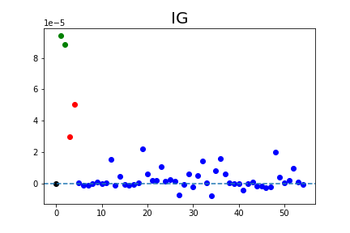

### Simulation 4

- 1 covariate has an effect (+ or -) that depends on a group
- 1 covariate has a negative effect
- 1 covariate has no effect
- The algorithm is trained with all the covariates

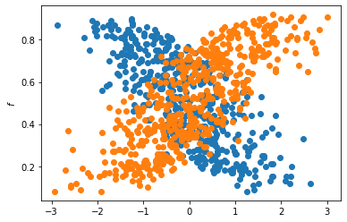

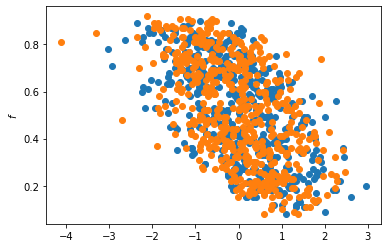

```
## [1] "AUC without covariates: 0.45"
```

```
## [1] "AUC with covariates: 0.694"
```

|  | GraphSVX | GRAD | GRADxInput | IG |
| --- | --- | --- | --- | --- |
| + | 0.60 | 0.47 | 0.47 | 0.53 |
| - | 0.53 | 0.84 | 0.54 | 0.43 |
| AUC | 0.55 | 0.27 | 0.61 | 0.73 |

- The black frames represent the estimated score for the additional variables $H$,
- The green frames represent the score for features where positive values are expected
- The red frames represent the score for features negative values are expected
- The blue frames are scores attributed to noise.

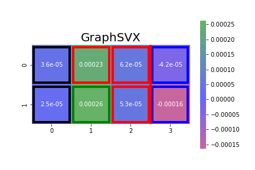

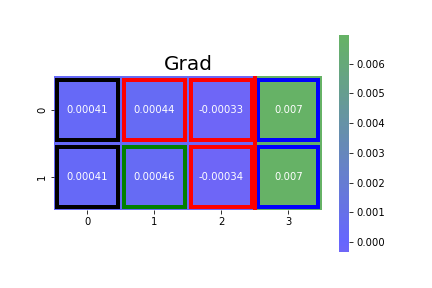

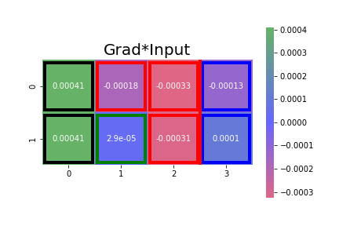

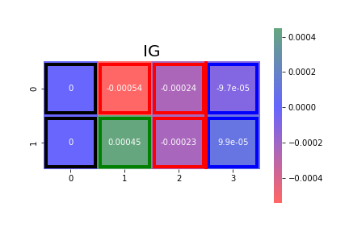

### Simulation 5

- 6 covariates have an effect (+ or -) that depends on a group
- 50 covariates have no effect

```
## [1] "AUC without covariates: 0.497"
```

```
## [1] "AUC with covariates: 0.748"
```

|  | GraphSVX | GRAD | GRADxInput | IG |
| --- | --- | --- | --- | --- |
| + | 0.54 | 0.64 | 0.61 | 0.62 |
| - | 0.47 | 0.69 | 0.34 | 0.32 |
| AUC | 0.51 | 0.52 | 0.79 | 0.84 |

- The black frames represent the estimated score for the additional variables $H$,
- The green frames represent the score for features where positive values are expected
- The red frames represent the score for features negative values are expected
- The blue frames are scores attributed to noise.

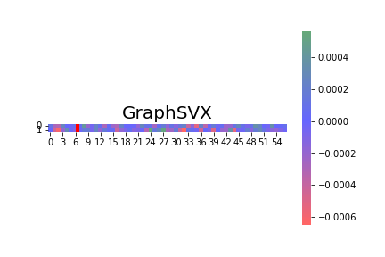

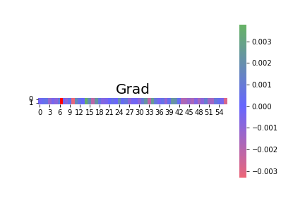

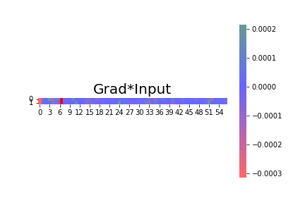

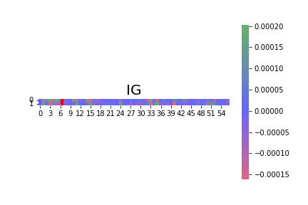

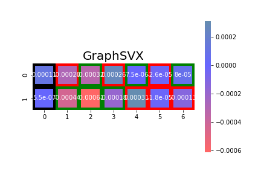

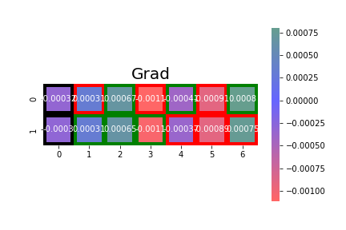

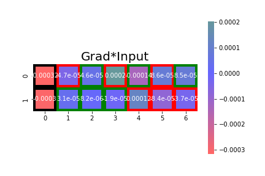

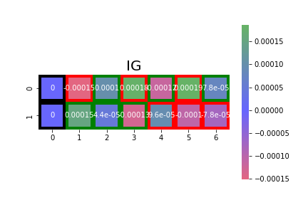